# 1. Making Necessary Study

# 4. Getting Data Ready

Splitting the Data in the ratio 70:30

```python
x=df.drop("Personal Loan",axis=1)
y=df["Personal Loan"]

from sklearn.model_selection import train_test_split
from sklearn.metrics import accuracy_score
from sklearn.metrics import recall_score

x_train,x_test,y_train,y_test=train_test_split(x,y,test_size=0.3,random_state=1)
```

```python
x_train.head()
#Converting Pandas Series to Dataframes Anew
#y_train=pd.DataFrame(x_train)
#print(x_train)
#y_test=pd.DataFrame(x_test)
#print(x_test)
```

|  | ID | Age | Experience | Income | ZIP Code | Family | CCAvg | Education | Mortgage | Securities Account | CD Account | Online | CreditCard | liability |
| --- | --- | --- | --- | --- | --- | --- | --- | --- | --- | --- | --- | --- | --- | --- |
| 1618 | 1619 | 29 | 3 | 29 | 94720 | 3 | 1.0 | 1 | 0 | 0 | 0 | 1 | 1 | 0 |
| 1547 | 1548 | 47 | 21 | 52 | 94720 | 1 | 1.2 | 2 | 194 | 0 | 0 | 0 | 0 | 0 |
| 438 | 439 | 58 | 32 | 113 | 93943 | 2 | 3.8 | 2 | 119 | 0 | 1 | 1 | 1 | 0 |
| 749 | 750 | 58 | 34 | 60 | 92008 | 4 | 1.6 | 2 | 0 | 0 | 0 | 0 | 1 | 0 |
| 4763 | 4764 | 51 | 25 | 173 | 95051 | 1 | 0.5 | 2 | 0 | 0 | 0 | 1 | 0 | 0 |

# 5.a Logistic Regression

```python
from sklearn import metrics

from sklearn.linear_model import LogisticRegression

# Fit the model on train
LR_model = LogisticRegression(solver="liblinear")
LR_model.fit(x_train, y_train)
#predict on test
y_predict = LR_model.predict(x_test)


coef_df_LR = pd.DataFrame(LR_model.coef_)
coef_df_LR['intercept'] = LR_model.intercept_
#coef_df
```

```python
#Testing the Scores of the Model

print("Model Score for Train Set : ", LR_model.score(x_train,y_train)*100,"%")


print("Model Score for Test Set : ", LR_model.score(x_test,y_test)*100,"%")
```

```
Model Score for Train Set :  91.95804195804196 %
Model Score for Test Set :  90.69293478260869 %
```

```python
coef_df_LR #Coefficient Matrix for Logistic Regression
```

|  | 0 | 1 | 2 | 3 | 4 | 5 | 6 | 7 | 8 | 9 | 10 | 11 | 12 | 13 | intercept |
| --- | --- | --- | --- | --- | --- | --- | --- | --- | --- | --- | --- | --- | --- | --- | --- |
| 0 | -0.000038 | 0.000348 | -0.001551 | 0.042975 | -0.000073 | 0.013561 | 0.00563 | 0.014392 | 0.000479 | 0.000871 | 0.003889 | 0.000164 | -0.000123 | -0.001486 | -0.000095 |

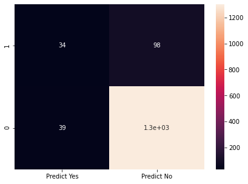

```python
Confusion_LR=metrics.confusion_matrix(y_test, y_predict, labels=[1, 0])

df_Confusion_LR = pd.DataFrame(Confusion_LR, index = [i for i in ["1","0"]],
                  columns = [i for i in ["Predict Yes","Predict No"]])
plt.figure(figsize = (7,5))
sns.heatmap(df_Confusion_LR, annot=True)
```

```python
df_Confusion_LR #Printing the confusion Matrix
```

|  | Predict Yes | Predict No |
| --- | --- | --- |
| 1 | 34 | 98 |
| 0 | 39 | 1301 |

```python
#This Cell can be skipped completely. This is to show what happens in the background for Precision and Recall
TP_LR = df_Confusion_LR["Predict Yes"]["1"]
TN_LR = df_Confusion_LR["Predict No"]["0"]
Total_Yes=df_Confusion_LR["Predict Yes"].sum()
Total_No=df_Confusion_LR["Predict No"].sum()
FP_LR = Total_Yes-TP_LR
FN_LR = Total_No-TN_LR
print("True Positives (TP) : ", TP_LR)
print("\nTotal True Predictions :",Total_Yes )
print("\nTotal proportion True Positives that have been rightly predicted : ",TP_LR *100/Total_Yes, "%")
print("\nTrue Negatives (TN) : ", TN_LR)
print("\nTotal False Predictions :",df_Confusion_LR["Predict No"].sum())
print("\nTotal proportion False predictions that have been rightly predicted : ", TN_LR*100/Total_No, "%" )

print("\nType I Error",df_Confusion_LR["Predict Yes"]["0"])
print("\nType II Error",df_Confusion_LR["Predict No"]["1"])
Precision= TP_LR/(TP_LR+FP_LR)
print ("\nPrecision of the above Model is : ", Precision)
Recall = TP_LR/(TP_LR+FN_LR)
print("\nRecall of the above Model is : ",Recall)
#print("Average precision-recall Score is : ", (Precision+Recall)/2)
```

```
True Positives (TP) :  34

Total True Predictions : 73

Total proportion True Positives that have been rightly predicted :  46.57534246575342 %

True Negatives (TN) :  1301

Total False Predictions : 1399

Total proportion False predictions that have been rightly predicted :  92.99499642601859 %

Type I Error 39

Type II Error 98

Precision of the above Model is :  0.4657534246575342

Recall of the above Model is :  0.25757575757575757
```

```python
#Instead of a Manual report like above, we can directly go for the appropriate function in Sklearn
from sklearn.metrics import recall_score
from sklearn.metrics import classification_report
print("Classification Report")
print(classification_report(y_test, y_predict, labels=[1, 0]))
Accuracy_LR = accuracy_score(y_test, y_predict)
Recall_LR = recall_score(y_test, y_predict)
print("\nThe Accuracy Score of Linear Regression Model is : ",Accuracy_LR)
print("\nThe Recall Score of Linear Regression Model is : ",Recall_LR)
```

```
Classification Report
              precision    recall  f1-score   support

           1       0.47      0.26      0.33       132
           0       0.93      0.97      0.95      1340

    accuracy                           0.91      1472
   macro avg       0.70      0.61      0.64      1472
weighted avg       0.89      0.91      0.89      1472


The Accuracy Score of Linear Regression Model is :  0.9069293478260869

The Recall Score of Linear Regression Model is :  0.25757575757575757
```

Please Note : The Next two cells are not my creation. They are copied from and modified as required from the link below. https://scikit-learn.org/stable/auto_examples/model_selection/plot_precision_recall.html

```python
from sklearn import svm, datasets
from sklearn.metrics import average_precision_score
classifier = svm.LinearSVC(random_state=1)
classifier.fit(x_train, y_train)
y_score = classifier.decision_function(x_test)
average_precision = average_precision_score(y_test, y_score)
print('Average precision-recall score: {0:0.2f}'.format(average_precision))
```

```
Average precision-recall score: 0.44
```

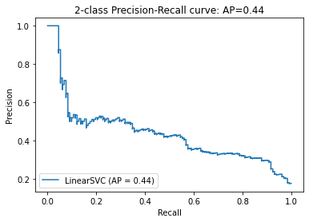

```python
from sklearn.metrics import precision_recall_curve
from sklearn.metrics import plot_precision_recall_curve
import matplotlib.pyplot as plt

disp = plot_precision_recall_curve(classifier, x_test, y_test)
disp.ax_.set_title('2-class Precision-Recall curve: AP={0:0.2f}'.format(average_precision))
```

# 5.c Naive Bayes

```python
from sklearn.naive_bayes import GaussianNB


diab_model = GaussianNB()

diab_model.fit(x_train, y_train.ravel())
diab_train_predict = diab_model.predict(x_train)
print(diab_model.score(x_test,y_test))
```

```
0.9191576086956522
```

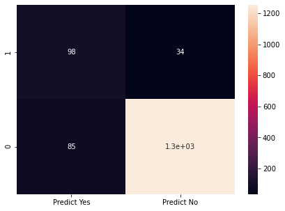

```python
#Confusion Matrix Checking
diab_test_predict = diab_model.predict(x_test)
confusion_Bayes=metrics.confusion_matrix(y_test, diab_test_predict, labels=[1, 0])

df_Confusion_Bayes = pd.DataFrame(confusion_Bayes, index = [i for i in ["1","0"]],
                  columns = [i for i in ["Predict Yes","Predict No"]])
plt.figure(figsize = (7,5))
sns.heatmap(df_Confusion_Bayes, annot=True)
```

```python
#checking Confusion Matrix
df_Confusion_Bayes
```

|  | Predict Yes | Predict No |
| --- | --- | --- |
| 1 | 98 | 34 |
| 0 | 85 | 1255 |

```python
from sklearn.metrics import classification_report
print("Classification Report")
print(classification_report(y_test, diab_test_predict, labels=[1, 0]))
Accuracy_Bayes = accuracy_score(y_test, diab_test_predict)
Recall_Bayes = recall_score(y_test, diab_test_predict)
print("\nThe Accuracy Score of Linear Regression Model is : ",Accuracy_Bayes)
print("\nThe Recall Score of Linear Regression Model is : ",Recall_Bayes)
```

```
Classification Report
              precision    recall  f1-score   support

           1       0.54      0.74      0.62       132
           0       0.97      0.94      0.95      1340

    accuracy                           0.92      1472
   macro avg       0.75      0.84      0.79      1472
weighted avg       0.93      0.92      0.92      1472


The Accuracy Score of Linear Regression Model is :  0.9191576086956522

The Recall Score of Linear Regression Model is :  0.7424242424242424
```

# 5.b KNN

```python
from sklearn.neighbors import KNeighborsClassifier
NNH = KNeighborsClassifier(n_neighbors= 5 , weights = 'distance' ) #Change the Number of neighbours for better modeling
NNH.fit(x_train, y_train)
predict_KNN = NNH.predict(x_test)
print(NNH.score(x_test,y_test))
```

```
0.904891304347826
```

```
Confusion Matrix
```

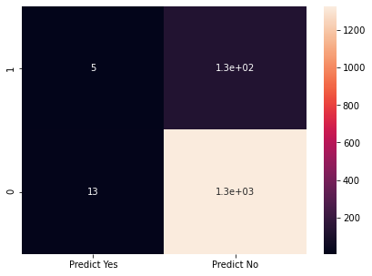

```python
print("Confusion Matrix")
Confusion_KNN=metrics.confusion_matrix(y_test, predict_KNN, labels=[1, 0])

df_Confusion_KNN = pd.DataFrame(Confusion_KNN, index = [i for i in ["1","0"]],
                  columns = [i for i in ["Predict Yes","Predict No"]])
plt.figure(figsize = (7,5))
sns.heatmap(df_Confusion_KNN, annot=True)
```

```python
df_Confusion_KNN
```

|  | Predict Yes | Predict No |
| --- | --- | --- |
| 1 | 5 | 127 |
| 0 | 13 | 1327 |

```python
print("Classification Report")
print(classification_report(y_test, predict_KNN, labels=[1, 0]))
Accuracy_KNN = accuracy_score(y_test, predict_KNN)
Recall_KNN = recall_score(y_test, predict_KNN)
print("\nThe Accuracy Score of Linear Regression Model is : ",Accuracy_KNN)
print("\nThe Recall Score of Linear Regression Model is : ",Recall_KNN)
```

```
Classification Report
              precision    recall  f1-score   support

           1       0.28      0.04      0.07       132
           0       0.91      0.99      0.95      1340

    accuracy                           0.90      1472
   macro avg       0.60      0.51      0.51      1472
weighted avg       0.86      0.90      0.87      1472


The Accuracy Score of Linear Regression Model is :  0.904891304347826

The Recall Score of Linear Regression Model is :  0.03787878787878788
```

# 6. Printing Confusion Matrix Again

```python
#Please Refer to the prints before for better quality printing.
print(df_Confusion_LR)
print(df_Confusion_Bayes)
print(df_Confusion_KNN)
```

```
   Predict Yes  Predict No
1           34          98
0           39        1301
   Predict Yes  Predict No
1           98          34
0           85        1255
   Predict Yes  Predict No
1            5         127
0           13        1327
```

```python
Judgement ={"Linear Regression":[Accuracy_LR,Recall_LR],"Naive Bayes":[Accuracy_Bayes,Recall_Bayes],"KNN":[Accuracy_KNN,Recall_KNN]}
```

```python
pd.DataFrame(Judgement,index=["Accuracy","Recall"])
```

|  | Linear Regression | Naive Bayes | KNN |
| --- | --- | --- | --- |
| Accuracy | 0.906929 | 0.919158 | 0.904891 |
| Recall | 0.257576 | 0.742424 | 0.037879 |

# 7. Reasoning for a Data Model

Taking a careful look at the above scores, we can compare and decide that although all of the Models provide roughly the same amount of accuracy, there is a significantly different amount of Recall generated by them.

Based on that we can say that highest amount of Recall is generated by Naive Bayes Model, where as KNN generates the worst amount of Recall. Hence, we have to choose Naive Bayes as our Model for this Dataset.